# SF Bay Microplastics Risk Characterization

Scott Coffin

12/15/2021

```r
library(tidyverse)
library(calecopal)
library(ssdtools)
library(DT)
library(plotly)
library(gridExtra)
library(grid)
library(wesanderson)
library(ggdark)
library(broom)
library(knitr)
library(ggdark)
library(viridis)
library(ggpubr)
library(ggsci)
```

# 1 Hazard Concentration and Alignment Parameters

```r
###### Choose concentration alignment parameters####
alpha.marine = 2.07 #table s4 from Kooi et al 2021 for marine surface water. length
alpha.freshwater = 2.64 #table s4 from Kooi et al 2021 for freshwater surface water. length

x2D_set = 5000 #100 #upper size range (microns)
x1D_set = 1 #1 #lower size range (microns)

#### Choose assessment factor (default = 1) ####
AF = 1

##### Choose hazard concentration and confidence intervals####
#particles/L
Threshold1 = 0.34 / AF
Threshold2 = 5.2 / AF
Threshold3 = 21.8 / AF
Threshold4 = 89.9 / AF

#Food dilution thresholds (particles/L aligned to 1-5,000 um)
Threshold1_food = 0.34 / AF
Threshold2_food = 5.2 / AF
Threshold3_food = 21.8 / AF
Threshold4_food = 89.9 / AF

#Oxidative stress thresholds (particles/L aligned to 1-5,000 um)
Threshold1_oxidative.stress = 35.3 / AF
Threshold2_oxidative.stress = 246.2 / AF
Threshold3_oxidative.stress = 1268.9 / AF
Threshold4_oxidative.stress = 4796.8 / AF
```

```r
# print table
kable(data.frame(
  Category = c("Hazard Concentrations (particles/L)"),
  "Threshold1" = Threshold1,
  "Threshold 2" = Threshold2,
  "Threshold 3" = Threshold3,
  "Threshold 4" = Threshold4))
```

| Category | Threshold1 | Threshold.2 | Threshold.3 | Threshold.4 |
| --- | --- | --- | --- | --- |
| Hazard Concentrations (particles/L) | 0.34 | 5.2 | 21.8 | 89.9 |

```r
#print table of sizes
kable(data.frame(
  Category = c("Concentration Alignment Parameters"),
  "Marine Alpha" = alpha.marine,
  "Freshwater Alpha" = alpha.freshwater,
  "lower_size_range_microns" = x1D_set,
  "upper_size_range_microns" = x2D_set))
```

| Category | Marine.Alpha | Freshwater.Alpha | lower_size_range_microns | upper_size_range_microns |
| --- | --- | --- | --- | --- |
| Concentration Alignment Parameters | 2.07 | 2.64 | 1 | 5000 |

To compare thresholds to concentrations observed in the environment, data from the following study is used:

Zhu, Xia, Keenan Munno, Jelena Grbic, Larissa Meghan Werbowski, Jacqueline Bikker, Annissa Ho, Edie Guo, et al. 2021. “Holistic Assessment of Microplastics and Other Anthropogenic Microdebris in an Urban Bay Sheds Light on Their Sources and Fate.” ACS ES&T Water, May, acsestwater.0c00292. https://doi.org/10.1021/acsestwater.0c00292.

```r
#data import
#SF bay data from Zhu et al (2021)
sfBay <- read.csv("data/SFBayData.csv", na.strings = "NA", stringsAsFactors = TRUE) %>%
  rename(sampleID = ï..sampleID,
          x1M = Min.particle.size.um,
         x2M = Max.particle.size.um) %>%
  mutate(Sample.Type = "sample")
```

## 1.1 Size-based Correction

Given an upper limit (UL) and lower limit (LL) of the measured and default size range, a dimensionless correction factor ($CF_{meas}$) for measured environmental concentrations may be calculated, which rescales the measured number concentrations for a certain size range to the number concentration for the microplastics default (D) size range (e.g. 1 to 5,000 um) (Koelmans et al 2020). Coefficients for the environmental-specific compartment for the power law distribution for length (L) with slope $\alpha_L$ is from Table S4 of Kooi et al (2021).

$CF_{Meas} = \frac{L^{1-a}_{UL,D} - L^{1-a}_{LL,D}}{L^{1-a}_{UL,M} - L^{1-a}_{LL,M}}$

```r
# Align Data

#function to derive correction factor (CF) from Koelmans et al (equation 2)
CFfnx = function(a = alpha, #default alpha from Koelmans et al (2020)
                 x2D = x2D_set, #set detault values to convert ranges to (1-5,000 um) #5mm is upper defuault
                 x1D = x1D_set, #1 um is lower default size
                 x2M, x1M){

  CF = (x2D^(1-a)-x1D^(1-a))/(x2M^(1-a)-x1M^(1-a))

  return(CF)
}
#verify it works (expected answer is 40.37)
#CFfnx(x1M = 333, x2M = 5000)


# correct aquatic concentrations for SF Bay
sfBay_new <- sfBay %>%
  mutate(CF = case_when(
    System == "Estuary" ~ CFfnx(a = alpha.marine, x1M = x1M, x2M = x2M, x1D = x1D_set, x2D = x2D_set),
   is.na(System) ~ CFfnx(a = alpha.freshwater, x1M = x1M, x2M = x2M, x1D = x1D_set, x2D = x2D_set))) %>%  #create new column with correction factor
  mutate(particle.L.master = particles.L.blank.corrected * CF) %>%
  rename(unaligned.particle.L.master = particles.L.blank.corrected) %>%
  filter(unaligned.particle.L.master > 0) %>%  #remove blanks. should convert to 1/2 LOQ...
  mutate(source = "SFEI") %>%
  mutate(Reference = "Zhu et. al 2021") %>%
  rename(Sampling.location = general.location) %>%
  dplyr::select(-c(particles.kg.blank.corrected,
                   particles.fish.blank.corrected)) %>%
  mutate(compartment = case_when(
    System == "Lake" ~ "freshwater",
    System == "River" ~ "freshwater",
    System == "Estuary" ~ "marine",
    System == "Ocean" ~ "marine",
  )) %>%
  mutate(Conc = particle.L.master) %>%
  mutate_if(is.character, as.factor)
```

### 1.1.1 SFBay Exceedances

```r
#make new dataframe to plot both histograms together
sampleSimpleSFEI <- sfBay_new %>%
  filter(source == "SFEI") %>%
  filter(sample.matrix.specific == "surface water") %>%
  drop_na(Conc) %>%
  droplevels()

#make new dataframe to plot both histograms together
dfSFEI <- rbind(sampleSimpleSFEI)#,food.dilution.simple)

#calculate exceedance
dfSFEI_exceedance <- dfSFEI %>%
  mutate(aboveThreshold = factor(case_when(
    Conc < Threshold1 ~ "below Threshold 1",
    Conc >= Threshold1 & Conc < Threshold2 ~ "above Threshold 1",
    Conc >= Threshold2 & Conc < Threshold3 ~ "above Threshold 2",
    Conc >= Threshold3 & Conc < Threshold4 ~ "above Threshold 3",
    Conc >= Threshold4 ~ "above Threshold 4"
  )))

#give summary stat for exceedance
exceedance <- dfSFEI_exceedance  %>%
  filter(Sample.Type == "sample") %>%
  dplyr::select(c(Conc, aboveThreshold)) %>%
  group_by(aboveThreshold) %>%
  dplyr::summarize(n = n()) %>%
  mutate(rel.freq = paste0(round(100 * n/sum(n), 0), "%"))

exceedance
```

```
## # A tibble: 4 x 3
##   aboveThreshold        n rel.freq
##   <fct>             <int> <chr>
## 1 above Threshold 1    12 13%
## 2 above Threshold 3     2 2%
## 3 above Threshold 4    36 38%
## 4 below Threshold 1    44 47%
```

#### 1.1.1.1 Sensitivity Analysis based on Alignments

Table S4 from Kooi et al (2021) includes the mean +- standard deviation for power law exponents. To test the sensitivity of this risk characterization based on alignments, a range of power law exponents for particle length are used within the upper and lower 99% of the data from which the power law exponent was derived. For marine surface water, the alpha value of 2.07 has a standard deviation of 0.03 (Kooi et al 2021). The mean plus or minus one, two, and three standard deviations are used to calculate risk exceedances to test sensitivity.

##### 1.1.1.1.1 Align

```r
alpha.marine.sd <- 0.03
alpha.marine.plus.one <- alpha.marine + alpha.marine.sd
alpha.marine.plus.two <- alpha.marine + (2 * alpha.marine.sd)
alpha.marine.plus.three <- alpha.marine + (3 * alpha.marine.sd)
alpha.marine.minus.one <- alpha.marine - alpha.marine.sd
alpha.marine.minus.two <- alpha.marine - (2 * alpha.marine.sd)
alpha.marine.minus.three <- alpha.marine - (3 * alpha.marine.sd)

#align data for different scenarios
sensitivity <- sfBay_new %>%
  #filter(source == "SFEI") %>%
  #filter(sample.matrix.specific == "surface water") %>%
  drop_na(Conc) %>%
  #derive correction factors
  mutate(plus1SD = CFfnx(a = alpha.marine.plus.one, x1M = x1M, x2M = x2M, x1D = x1D_set, x2D = x2D_set),
         plus2SD = CFfnx(a = alpha.marine.plus.two, x1M = x1M, x2M = x2M, x1D = x1D_set, x2D = x2D_set),
         plus3SD = CFfnx(a = alpha.marine.plus.three, x1M = x1M, x2M = x2M, x1D = x1D_set, x2D = x2D_set),
         minus1SD = CFfnx(a = alpha.marine.minus.one, x1M = x1M, x2M = x2M, x1D = x1D_set, x2D = x2D_set),
         minus2SD = CFfnx(a = alpha.marine.minus.two, x1M = x1M, x2M = x2M, x1D = x1D_set, x2D = x2D_set),
         minus3SD = CFfnx(a = alpha.marine.minus.three, x1M = x1M, x2M = x2M, x1D = x1D_set, x2D = x2D_set)) %>%
  #apply correction fcators
  mutate(conc.plus1 = unaligned.particle.L.master * plus1SD,
         conc.plus2 = unaligned.particle.L.master * plus2SD,
         conc.plus3 = unaligned.particle.L.master * plus3SD,
         conc.minus1 = unaligned.particle.L.master * minus1SD,
         conc.minus2 = unaligned.particle.L.master * minus2SD,
         conc.minus3 = unaligned.particle.L.master * minus3SD)
```

##### 1.1.1.1.2 Compare to thresholds

```r
sensitivity.analysis <- sensitivity %>%
  filter(source == "SFEI") %>%
  filter(sample.matrix.specific == "surface water") %>%
  #just select concentrations
  dplyr::select(c(Conc, conc.plus1, conc.plus2, conc.plus3, conc.minus1, conc.minus2, conc.minus3)) %>%
  #make long data
  pivot_longer(everything()) %>%
  mutate(aboveThreshold = factor(case_when(
    value < Threshold1_food ~ "below Threshold 1",
    value >= Threshold1_food & value < Threshold2_food ~ "above Threshold 1",
    value >= Threshold2_food & value < Threshold3_food ~ "above Threshold 2",
    value >= Threshold3_food & value < Threshold4_food ~ "above Threshold 3",
    value >= Threshold4_food ~ "above Threshold 4"
  ))) %>%
  group_by(aboveThreshold, name) %>%
  dplyr::summarize(n = n()) %>%
  mutate(rel.freq = paste0(round(100 * n/sum(n), 0), "%"))

sensitivity.analysis
```

```
## # A tibble: 30 x 4
## # Groups:   aboveThreshold [5]
##    aboveThreshold    name            n rel.freq
##    <fct>             <chr>       <int> <chr>
##  1 above Threshold 1 Conc           12 13%
##  2 above Threshold 1 conc.minus1    11 12%
##  3 above Threshold 1 conc.minus2     9 10%
##  4 above Threshold 1 conc.minus3     8 9%
##  5 above Threshold 1 conc.plus1     14 15%
##  6 above Threshold 1 conc.plus2     18 20%
##  7 above Threshold 1 conc.plus3     19 21%
##  8 above Threshold 2 conc.minus3     1 50%
##  9 above Threshold 2 conc.plus3      1 50%
## 10 above Threshold 3 Conc            2 18%
## # ... with 20 more rows
```

##### 1.1.1.1.3 Plot

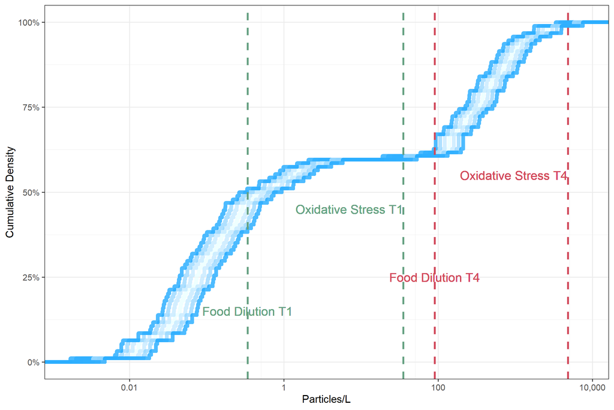

```r
#ECDF by System
sfBayECDF_sensitivity <- sensitivity %>%
  filter(source == "SFEI") %>%
  filter(sample.matrix.specific == "surface water") %>%
  #just select concentrations
  dplyr::select(c(Conc, conc.plus1, conc.plus2, conc.plus3, conc.minus1, conc.minus2, conc.minus3)) %>%
  #make long data
  pivot_longer(everything()) %>%
  mutate(name = as.factor(name)) %>%
  ggplot() +
 # stat_ecdf(aes(x = value, color = name),
  #          geom = "point", size = 1, alpha = 0.5) +
  stat_ecdf(aes(x = value, color = name),geom = "step", linetype = 'solid', alpha = 0.7, size = 2.5) +
  #color
  scale_color_manual(name = "Alignment Uncertanties",
                     values = c("Conc" = "#e8ffff",
                                "conc.minus1" = "#bfe6ff",
                                "conc.plus1" = "#bfe6ff",
                                "conc.minus2" = "#8cd3ff",
                                "conc.plus2" = "#8cd3ff",
                                "conc.minus3" = "#009dff",
                                "conc.plus3" = "#009dff"),
                     labels = c("Mean",
                                "68th Percentile",
                                "68th Percentile",
                                "95th Percentile",
                                "95th Percentile",
                                "99.7th Percentile",
                                "99.7th Percentile")) +
  # ##Food Dilution thresholds
  geom_vline(xintercept = Threshold1_food, linetype = 'dashed', color = "#66a182", size = 1.3) +
  geom_vline(xintercept = Threshold4_food, linetype = 'dashed',
             color = "#d1495b",
             size = 1.3) +
  geom_text(label = "Food Dilution T1", color = "#66a182" , x = Threshold1_food, y = 0.15, size = 6)+
   geom_text(label = "Food Dilution T4", color = "#d1495b",
            x = Threshold4_food,
            y = 0.25, size = 6)+
  ###Oxidative Stress thresholds
  geom_vline(xintercept = Threshold1_oxidative.stress, linetype = 'dashed',
             color = "#66a182",#"#00798c",
             size = 1.3) +
  geom_vline(xintercept = Threshold4_oxidative.stress, linetype = 'dashed',
             color = "#d1495b",
             size = 1.3) +
  geom_text(label = "Oxidative Stress T1", color = "#66a182",#'#edae49',
            x = Threshold1_oxidative.stress - 0.8 * Threshold1_oxidative.stress,
            y = 0.45, size = 6) +
  geom_text(label = "Oxidative Stress T4", color = "#d1495b", x =
              Threshold4_oxidative.stress - 0.8 * Threshold4_oxidative.stress,
            y = 0.55, size = 6)+
    ylab("Cumulative Density") +
  xlab("Particles/L") +
  #xlab(paste0("Particles/L (" ,x1D_set, " to ", x2D_set, "um)"))+
  scale_y_continuous(labels = scales::percent)+
  coord_trans(x = "log10") +
  scale_x_continuous(breaks = scales::trans_breaks("log10", function(x) 10^x),labels = comma_signif)+
  #annotation_logticks(sides = "b")+ #log scale rick marks on bottom
  theme.type +
  theme(legend.title = element_blank(),
        legend.position = "none")
  #labs(title = "Global Surface Water Marine Microplastics Concentrations",
   #    subtitle = paste("Particles/L corrected to:",x1D_set, "to", x2D_set, "um"),
    #   caption = paste("Concentration data from Adams et al (2019): 23 studies, 57 sampling locations, n = 377; corrected for size ranges. Alpha = ",alpha))

sfBayECDF_sensitivity
```

### 1.1.2 Risk Characterization Histogram (SFBay)

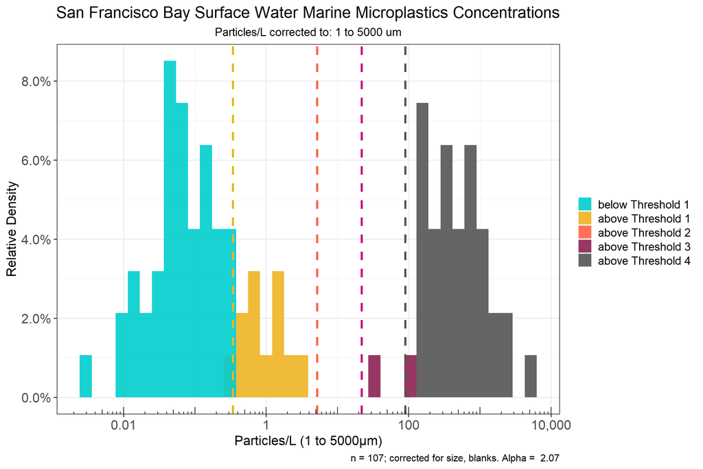

```r
#generate plot
dfSFEI_exceedance %>%
 # filter(Conc > 0) %>%
  filter(Sample.Type == "sample") %>%
  ggplot(aes(x = Conc, fill = aboveThreshold))+
  geom_histogram(aes(y = ..count../sum(..count..)),bins = 38, alpha = 0.9, position = "identity") +
  #geom_text(aes(x = Threshold1- 0.5*Threshold1, y = 0.045), label = paste(Threshold1,"particles/L"),  color = "goldenrod2") +
  #geom_text(aes(x = Threshold1- 0.5*Threshold1, y = 0.055), label = ("Threshold1"),  color = "goldenrod2") +
  geom_vline(xintercept = Threshold1, linetype = 'dashed', color = 'goldenrod2', size = 1.3) +
  geom_vline(xintercept = Threshold2, linetype = 'dashed', color = 'tomato1', size = 1.3) +
  geom_vline(xintercept = Threshold3, linetype = 'dashed', color =  'mediumvioletred', size = 1.3) +
  geom_vline(xintercept = Threshold4, linetype = 'dashed', color =  'gray33', size = 1.3) +
  #geom_text(label = "Threshold 1", color = 'goldenrod2', x = log10(Threshold1) - 0.8*log10(Threshold1), y = 0.055, size = 6)+
#   geom_text(label = "Threshold 2", color = 'tomato1', x = log10(Threshold2) - 0.8*log10(Threshold2), y = 0.055, size = 6)+
 #  geom_text(label = "Threshold 3", color = 'mediumvioletred', x = log10(Threshold3) - 0.8*log10(Threshold3), y = 0.055, size = 6)+
  # geom_text(label = "Threshold 4", color = 'gray33', x = Threshold4 - 0.8*log10(Threshold4), y = 0.055, size = 6)+
  scale_x_continuous(breaks = scales::trans_breaks("log10", function(x) 10^x),labels = comma_signif, trans = "log10")+
  annotation_logticks(sides = "b")+ #log scale rick marks on bottom
  #coord_cartesian(xlim = c(0,100000000)) +
  #scale_x_continuous(labels = scales::scientific) +
   xlab(paste0("Particles/L (" ,x1D_set, " to ", x2D_set, "μm)")) +
  scale_y_continuous(name = "Relative Density", labels = scales::percent)+
  scale_fill_manual(values = c("below Threshold 1"= "cyan3",
                               "above Threshold 1" = "goldenrod2",
                               "above Threshold 2" = "tomato1",
                               "above Threshold 3" = "violetred4",
                               "above Threshold 4" = "gray33")) +
  labs(title = "San Francisco Bay Surface Water Marine Microplastics Concentrations",
       subtitle = paste("Particles/L corrected to:",x1D_set, "to", x2D_set, "um"),
       caption = paste("n = 107; corrected for size, blanks. Alpha = ",alpha.marine))+
  theme.type +
  theme(#legend.position = "none",
    plot.title = element_text(hjust = 0.5, size = 20),
        axis.title = element_text(size = 16),
        axis.text =  element_text(size = 16),
        legend.text = element_text(size =14),
        legend.title = element_blank(),
        plot.subtitle = element_text(hjust = 0.5, size = 14))
```

### ECDF (SF Bay)

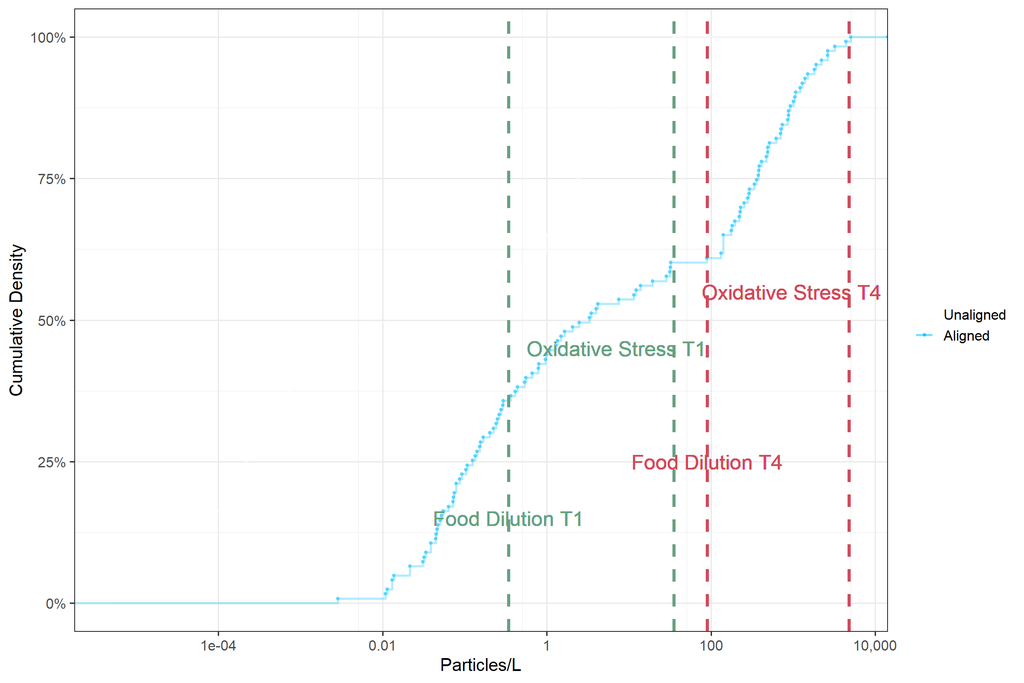

```r
vals <- c("Unaligned" = "white", "Aligned" = "deepskyblue")

#ECDF by System
sfBayECDF <- sfBay_new %>%
  filter(source == "SFEI") %>%
  drop_na(particle.L.master) %>%
  filter(particle.L.master > 0.0) %>%
    filter(System %in% c("Ocean", "Estuary")) %>%
  ggplot() +
     #unaligned
  stat_ecdf(aes(x = unaligned.particle.L.master, color = "Unaligned"),
            geom = "point", size = 1, alpha = 0.5) +
  stat_ecdf(aes(x = unaligned.particle.L.master, color = "Unaligned"),geom = "step", linetype = 'solid', alpha = 0.3, size = 1) +
  #aligned
  stat_ecdf(aes(x = particle.L.master, color = "Aligned"),
            geom = "point", size = 1, alpha = 0.5) +
  stat_ecdf(aes(x = particle.L.master, color = "Aligned"),geom = "step", linetype = 'solid', alpha = 0.3, size = 1) +
  #color
  scale_color_manual(name = "alignment",
                     values = vals) +
  # ##Food Dilution thresholds
  geom_vline(xintercept = Threshold1_food, linetype = 'dashed', color = "#66a182", size = 1.3) +
  #geom_vline(xintercept = Threshold2, linetype = 'dashed', color = "#66a182" , size = 1.3) +
  #geom_vline(xintercept = Threshold3, linetype = 'dashed', color =     '#edae49', size = 1.3) +
  geom_vline(xintercept = Threshold4_food, linetype = 'dashed',
             color = "#d1495b",
             size = 1.3) +
  geom_text(label = "Food Dilution T1", color = "#66a182" , x = Threshold1_food, y = 0.15, size = 6)+
 # geom_text(label = "Threshold 2", color = "#66a182" , x = Threshold2, y = 0.22, size = 6)+
  #geom_text(label = "Threshold 3", color = '#edae49', x = Threshold3, y = 0.35, size = 6)+
  geom_text(label = "Food Dilution T4", color = "#d1495b",
            x = Threshold4_food,
            y = 0.25, size = 6)+
  ###Oxidative Stress thresholds
  geom_vline(xintercept = Threshold1_oxidative.stress, linetype = 'dashed',
             color = "#66a182",#"#00798c",
             size = 1.3) +
  geom_vline(xintercept = Threshold4_oxidative.stress, linetype = 'dashed',
             color = "#d1495b",
             size = 1.3) +
  geom_text(label = "Oxidative Stress T1", color = "#66a182",#'#edae49',
            x = Threshold1_oxidative.stress - 0.8 * Threshold1_oxidative.stress,
            y = 0.45, size = 6) +
  geom_text(label = "Oxidative Stress T4", color = "#d1495b", x =
              Threshold4_oxidative.stress - 0.8 * Threshold4_oxidative.stress,
            y = 0.55, size = 6)+
    ylab("Cumulative Density") +
  xlab("Particles/L") +
  #xlab(paste0("Particles/L (" ,x1D_set, " to ", x2D_set, "um)"))+
  scale_y_continuous(labels = scales::percent)+
  coord_trans(x = "log10") +
  scale_x_continuous(breaks = scales::trans_breaks("log10", function(x) 10^x),labels = comma_signif)+
  #annotation_logticks(sides = "b")+ #log scale rick marks on bottom
  theme.type +
  theme(legend.title = element_blank())
  #labs(title = "Global Surface Water Marine Microplastics Concentrations",
   #    subtitle = paste("Particles/L corrected to:",x1D_set, "to", x2D_set, "um"),
    #   caption = paste("Concentration data from Adams et al (2019): 23 studies, 57 sampling locations, n = 377; corrected for size ranges. Alpha = ",alpha))

sfBayECDF
```

```r
ggsave(plot =sfBayECDF,
       filename = "sfBayECDF.jpeg",
       path = ".output/",
       width = 10, height = 6, units = "in",
       bg = "white",
       dpi = 300)
```